# 36-315 Homework 07, Fall 2019

Eu Jing Chua

Due Wed Oct 30 2019 (11:00pm ET) on Canvas

# Homework 07: Higher Dimensional Continuous Data

*General instructions for all assignments*:

# Problem 0

Using the tidyverse style guide.

```r
library(tidyverse)
library(viridis)
```

```r
knitr::opts_chunk$set(warning = FALSE, message = FALSE)

eujingc_315_theme <-  theme_bw() +
  theme(axis.text = element_text(size = 12),
        plot.title = element_text(size = 20, face = "bold", hjust = 0),
        plot.subtitle = element_text(size = 14, face = "italic", hjust = 0),
        text = element_text(size = 14, face = "bold", color = "darkslategrey"))
```

# Problem 1

## Part (a)

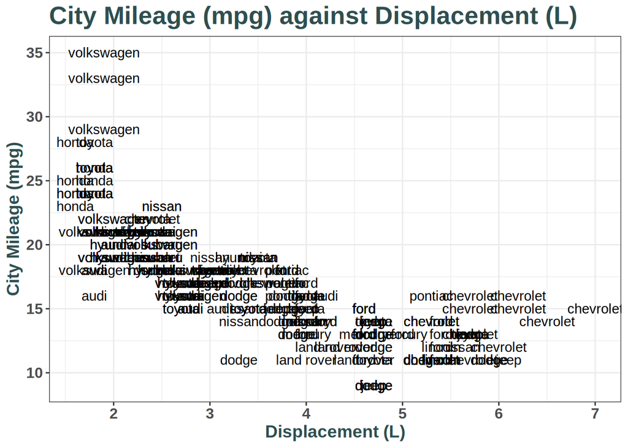

```r
ggplot(mpg, aes(x = displ, y = cty)) +
    geom_text(aes(label = manufacturer)) +
    labs(x = "Displacement (L)", y = "City Mileage (mpg)",
         title = "City Mileage (mpg) against Displacement (L)") +
    eujingc_315_theme
```

## Part (b)

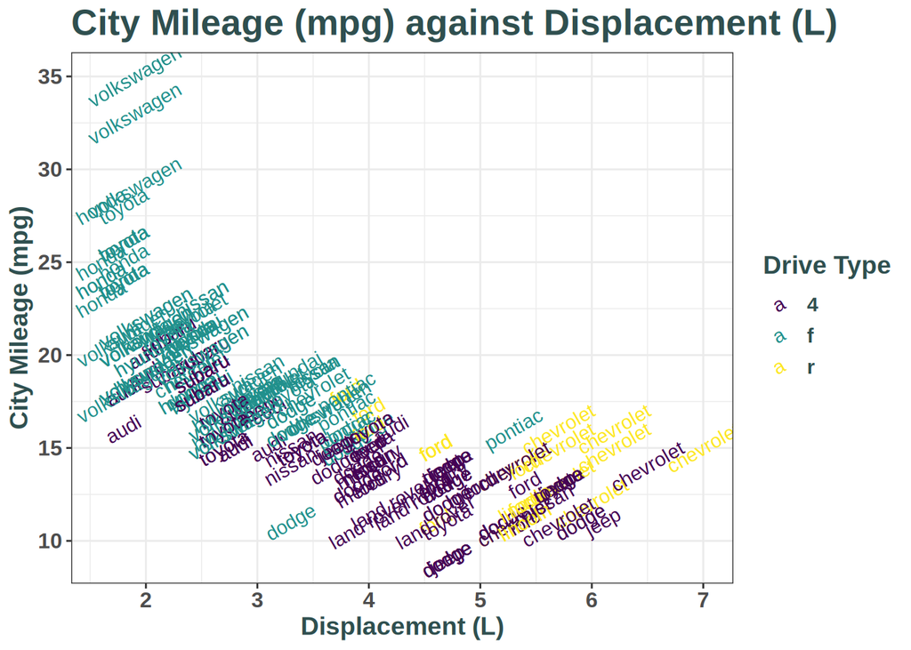

```r
ggplot(mpg, aes(x = displ, y = cty)) +
    geom_text(angle = 30, aes(label = manufacturer, color = drv)) +
    scale_color_viridis(discrete = TRUE) +
    labs(x = "Displacement (L)", y = "City Mileage (mpg)",
         color = "Drive Type",
         title = "City Mileage (mpg) against Displacement (L)") +
    eujingc_315_theme
```

## Part (c)

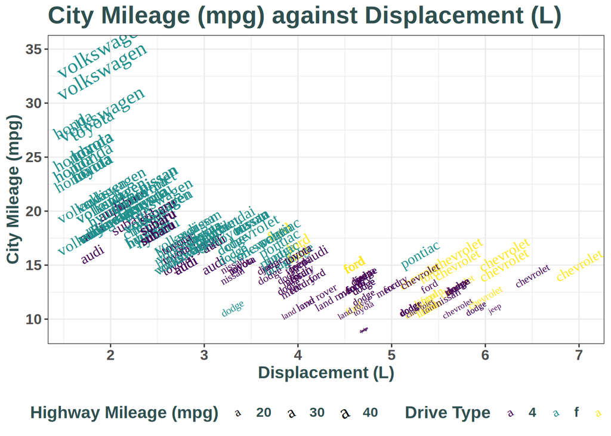

```r
ggplot(mpg, aes(x = displ, y = cty)) +
    geom_text(angle = 30, family = "Times New Roman",
              aes(label = manufacturer, color = drv, size = hwy)) +
    scale_color_viridis(discrete = TRUE) +
    labs(x = "Displacement (L)", y = "City Mileage (mpg)",
         color = "Drive Type", size = "Highway Mileage (mpg)",
         title = "City Mileage (mpg) against Displacement (L)") +
    eujingc_315_theme +
    theme(legend.position = "bottom")
```

## Part (d)

```
The graph shows the relationship between four variables. Firstly, we can see a clustering of drive types based on the city mileage and displacement, where each drive type is well clustered and close to each other in terms of city mileage and displacement.

There is also a positive correlation between city and highway mileage, where higher city mileage correlates with higher highway mileage.

There is also a negative correlation between city mileage and engine displacement, where higher engine displacement correlates with lower city mileage.
```

# Problem 2

## Part (a)

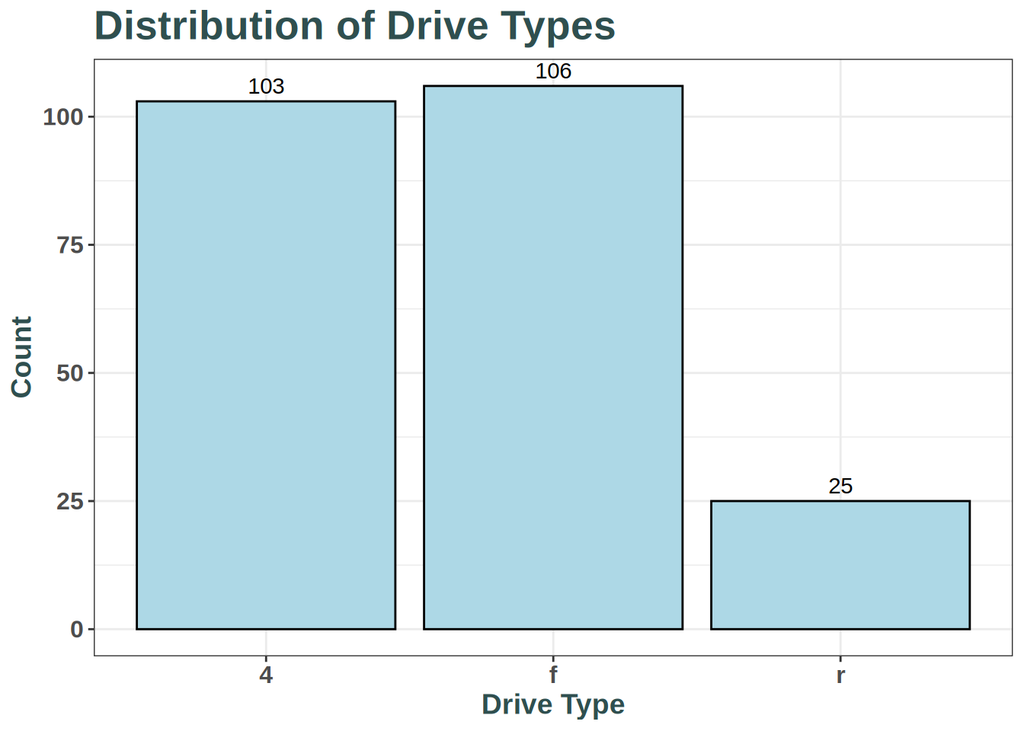

```r
ggplot(mpg, aes(x = drv)) +
    geom_bar(color = "black", fill = "lightblue") +
    geom_text(stat = "count", vjust = -0.5,
              aes(y = ..count.., label = ..count..)) +
    labs(x = "Drive Type", y = "Count",
         title = "Distribution of Drive Types") +
    eujingc_315_theme
```

## Part (b)

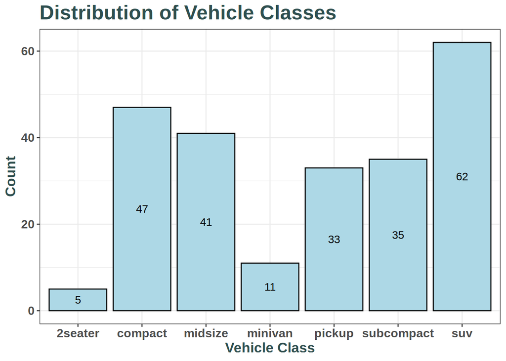

```r
ggplot(mpg, aes(x = class)) +
    geom_bar(color = "black", fill = "lightblue") +
    geom_text(stat = "count",
              aes(y = ..count.. / 2, label = ..count..)) +
    labs(x = "Vehicle Class", y = "Count",
         title = "Distribution of Vehicle Classes") +
    eujingc_315_theme
```

## Part (c)

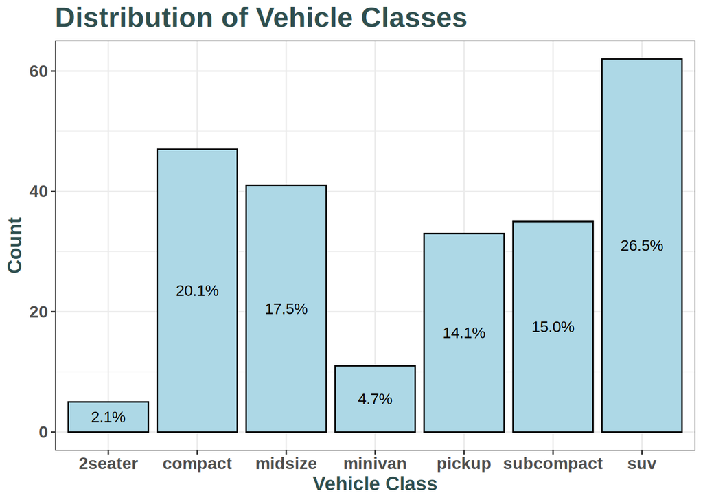

```r
ggplot(mpg, aes(x = class)) +
    geom_bar(color = "black", fill = "lightblue") +
    geom_text(stat = "count",
              aes(y = ..count.. / 2,
                  label = scales::percent((..count..) / sum(..count..)))) +
    labs(x = "Vehicle Class", y = "Count",
         title = "Distribution of Vehicle Classes") +
    eujingc_315_theme
```

# Problem 3

## Part a.

```r
olive <- read_csv("https://raw.githubusercontent.com/mateyneykov/315_code_data/master/data/olive_oil.csv")
olive_cont <- olive %>% select(-c(area, region))
olive_cont_scale <- olive_cont %>% mutate_each(scale)
dist_olive <- dist(olive_cont_scale)
```

## Part b.

Information about the dendrogram is stored in the clustering object, such as the height of each point in the dendrogram, the distance metric used between points, the method of clustering, etc. In this case, the method used is complete linkage.

```r
hc_olive_complete <- hclust(dist_olive, method = "complete")
names(hc_olive_complete)
```

```
## [1] "merge"       "height"      "order"       "labels"      "method"
## [6] "call"        "dist.method"
```

## Part c.

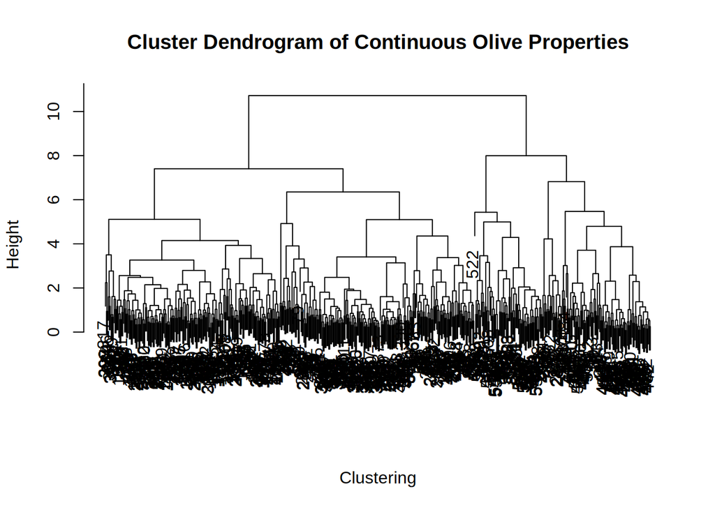

```r
plot(hc_olive_complete,
     xlab = "Clustering", sub = "",
     main = "Cluster Dendrogram of Continuous Olive Properties")
```

## Part d.

The maximum distance at which two groups of observations are linked in this dataset is slightly more than 10, as seen from the above dendrogram.

## Part e.

About two-thirds of the data are in one cluster and the remaining third in the other cluster when we look at the final link at the top.

## Part f.

The object returned by `cutree` is a vector with each element corresponding to the cluster of the corresponding point in the original data frame. In this case, there are 572 elements in the vector returned.

```r
labels_complete_2 <- cutree(hc_olive_complete, k = 2)
```

## Part g.

The actual proportions of each cluster are 0.32 and 0.68 respectively, which is close to what we inspected visually.

```r
table(labels_complete_2) / nrow(olive)
```

```
## labels_complete_2
##         1         2
## 0.3234266 0.6765734
```

## Part h.

The cluster labels do not seem to correspond well to the area variable. We can see many areas that are split apart in terms of clustering results, such as area 3 in yellow which is split into two groups, 1 and 3. We see the same for area 1 in purple, which is split into 1 and 2 by the clustering. Only area 2 in teal is not split apart.

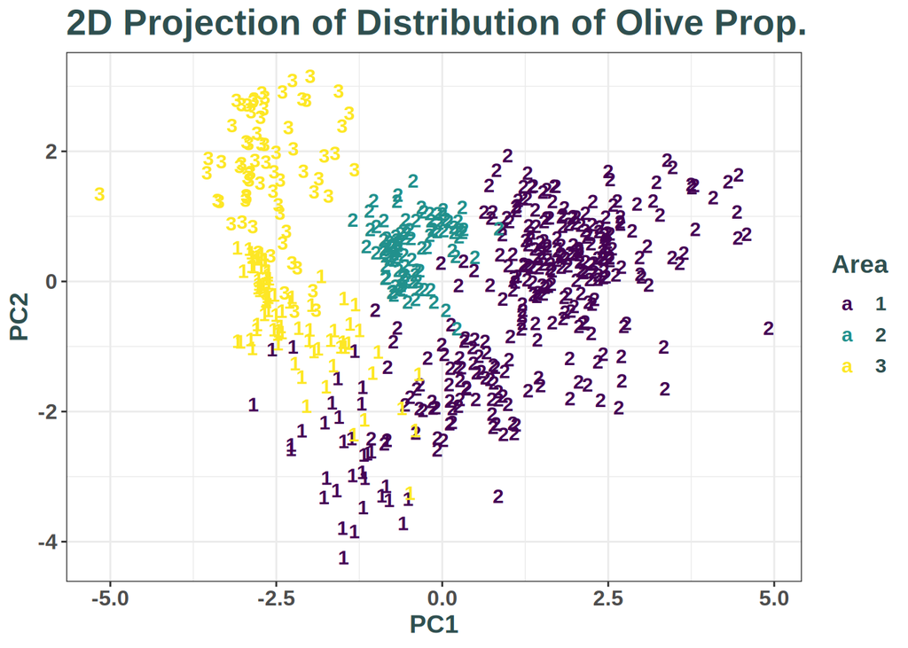

```r
labels_complete_3 <- cutree(hc_olive_complete, k = 3)
olive_mds <- as.data.frame(cmdscale(dist_olive, k = 2))
olive_mds$area <- factor(olive$area)
olive_mds$region <- factor(olive$region)
olive_mds$cluster <- factor(labels_complete_3)

ggplot(olive_mds) +
    geom_text(fontface = "bold",
              aes(x = V1, y = V2, color = area, label = cluster)) +
    scale_color_viridis(discrete = TRUE) +
    labs(x = "PC1", y = "PC2", color = "Area",
         title = "2D Projection of Distribution of Olive Prop.") +
    eujingc_315_theme
```